# stats415hw7

Siqi Li

11/18/2019

```r
library(ISLR)
library(tidyverse)
library(SignifReg)
library(leaps)
library(boot)
library(caret)
library(glmnet)
library(pls)
# check if there's NA in the data
College %>% nrow()
```

```
## [1] 777
```

```r
College %>% na.omit() %>% nrow()
```

```
## [1] 777
```

As shown above, there’s no NAs in our dataset.  
Split data:

```r
set.seed(234)
# choose 30% of the data at random for testing
test_size <- floor(nrow(College) * 0.30)
test_id <- sample(1:nrow(College), test_size)
testCollege <- College[test_id, ]
# the rest of data for testing:
trainCollege <- College[-test_id, ]
```

Define a new variable Accept/Apps:

```r
# get the new variable in both testing and training data:
trainCollege <- trainCollege %>% mutate(AcceptAppsRatio = Accept / Apps)
testCollege <- testCollege %>% mutate(AcceptAppsRatio = Accept / Apps)
```

Obtain matrix of predictors:

```r
X_train <- model.matrix(AcceptAppsRatio ~ ., trainCollege)[,-1]
Y_train <- trainCollege$AcceptAppsRatio
X_test <- model.matrix(AcceptAppsRatio ~ ., testCollege)[,-1]
Y_test <- testCollege$AcceptAppsRatio
```

1. Fit a ridge regression model on the training set, with λ chosen by 10-fold cross-validation.

```r
grid = 10^seq(10, -6, length=100)

ridge.mod = glmnet(X_train, Y_train, alpha=0, lambda=grid)


# compute the 10-fold crossvalidated error for the selected lambda (bestlam)
cv.out.ridge = cv.glmnet(X_train, Y_train, alpha=0, lambda=grid, nfolds = 10)
bestlam.ridge = cv.out.ridge$lambda.min
bestlam.ridge
```

```
## [1] 0.0008111308
```

Plot the coefficients’ solution paths.

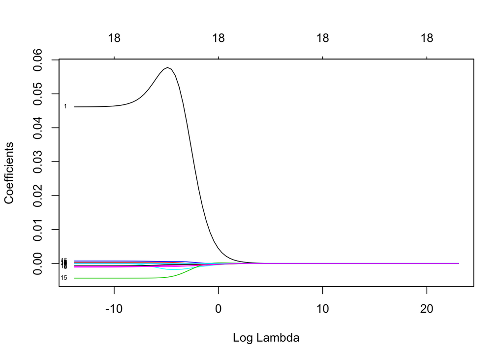

```r
plot(ridge.mod, xvar = "lambda", label = TRUE)
```

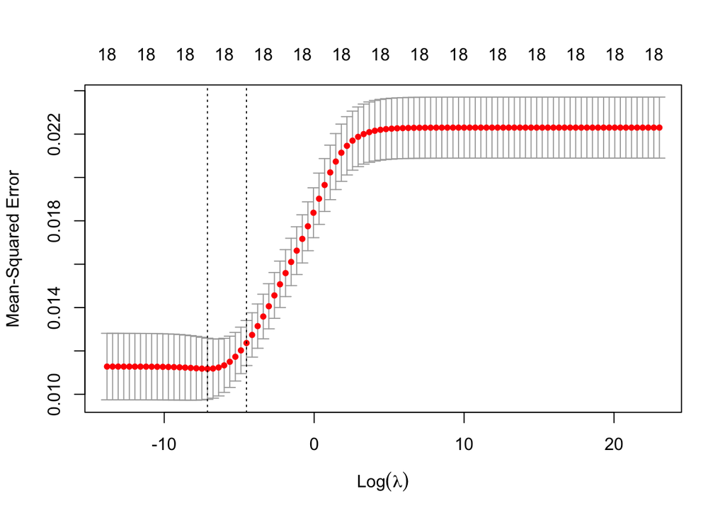

```r
plot(cv.out.ridge)
```

Report the training, cross-validated, and test errors:

```r
# training error:
ridge.pred_train = predict(ridge.mod, s=bestlam.ridge, newx=X_train)
trainerror_ridge = mean((ridge.pred_train- Y_train)^2)
trainerror_ridge
```

```
## [1] 0.009577558
```

```r
# testing error:
ridge.pred_test = predict(ridge.mod, s=bestlam.ridge, newx=X_test)
testerror_ridge = mean((ridge.pred_test - Y_test)^2)
testerror_ridge
```

```
## [1] 0.008628103
```

```r
# crossvalidated error
lambda.grid = cv.out.ridge$lambda # grid of lambdas used by cv.glmnet()
mses = cv.out.ridge$cvm # mean crossvalidated error (MSE) for each lambda (averaged over the 10 folds)
cv_error_ridge = mses[which(lambda.grid == bestlam.ridge)] # this is the crossvalidated error (MSE)
print(cv_error_ridge)
```

```
## [1] 0.01117657
```

(b)  
Fit a lasso model on the training set, with λ chosen by 10-fold cross-validation.

```r
grid = 10^seq(10, -6, length=100)

lasso.mod = glmnet(X_train, Y_train, alpha=1, lambda=grid)

#cv.out.lasso = cv.glmnet(X_train, Y_train, alpha=1)
cv.out.lasso = cv.glmnet(X_train, Y_train, alpha=1, lambda=grid, nfolds = 10)
bestlam.lasso = cv.out.lasso$lambda.min
bestlam.lasso
```

```
## [1] 0.001176812
```

Plot the coefficients’ solution paths.

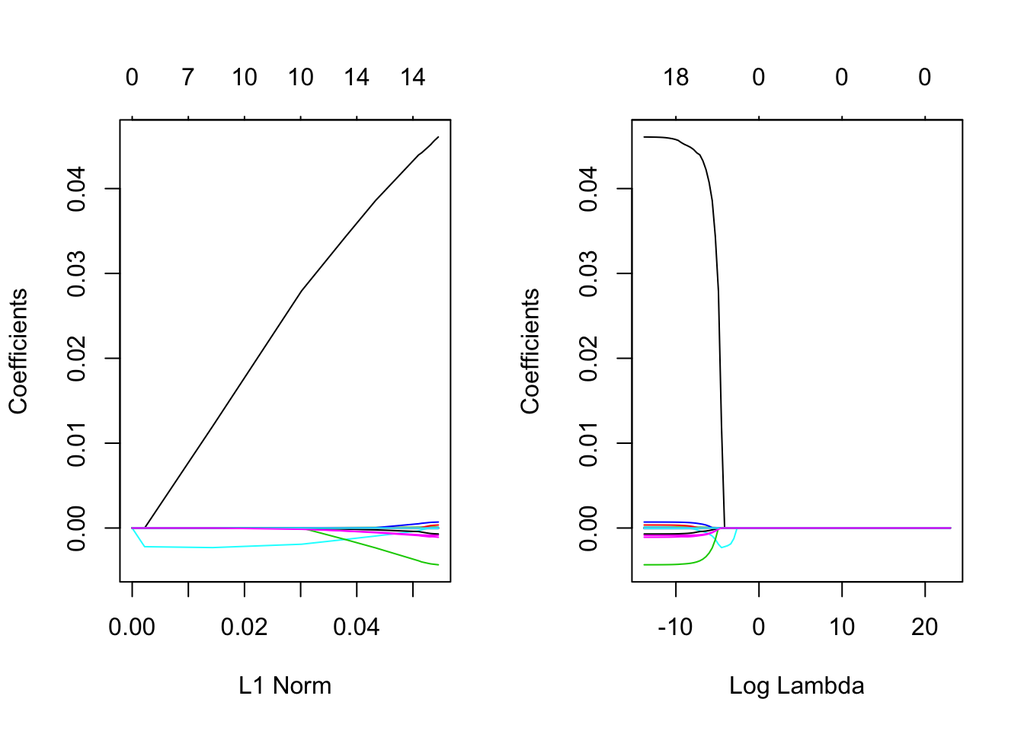

```r
par(mfrow = c(1, 2))
plot(lasso.mod) # plot w/ L1 norm
plot(lasso.mod, xvar = "lambda", label = TRUE) # plot w/ lambda
```

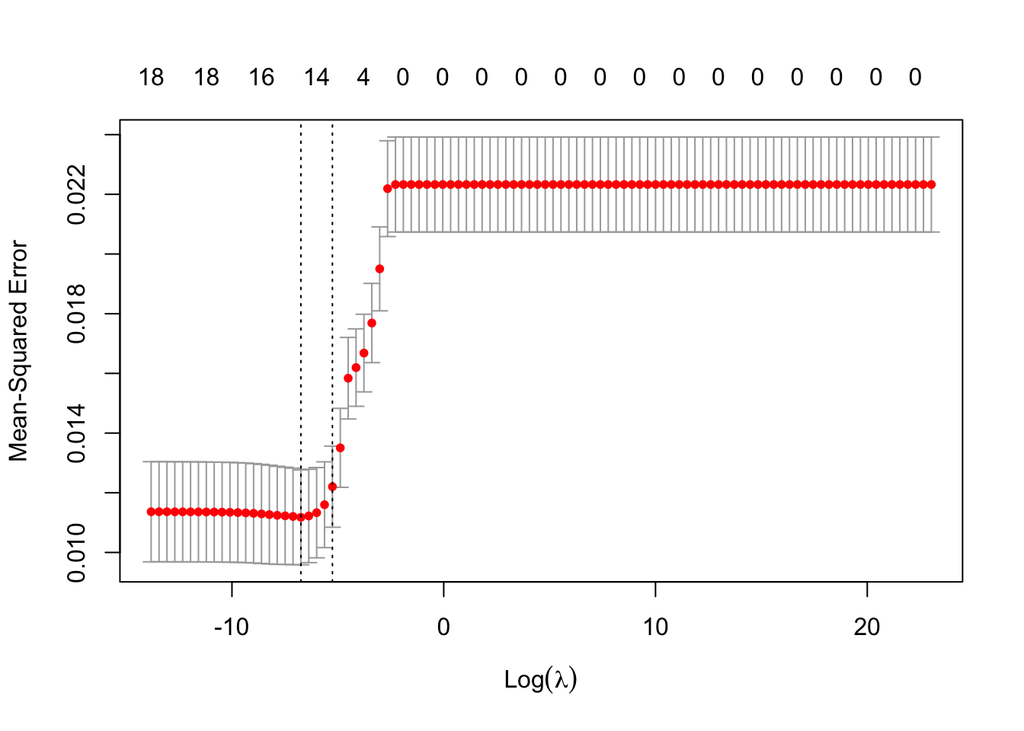

```r
par(mfrow = c(1, 1))
plot(cv.out.lasso)
```

Report which variables are included in the model, and the training, cross- validated, and test errors:

```r
# training error:
lasso.pred_train = predict(lasso.mod, s=bestlam.lasso, newx=X_train)
trainerror_lasso = mean((lasso.pred_train- Y_train)^2)
trainerror_lasso
```

```
## [1] 0.009592289
```

```r
# testing error:
lasso.pred_test = predict(lasso.mod, s=bestlam.lasso, newx=X_test)
testerror_lasso = mean((lasso.pred_test - Y_test)^2)
testerror_lasso
```

```
## [1] 0.008504568
```

```r
# crossvalidated error
lambda.grid = cv.out.lasso$lambda # grid of lambdas used by cv.glmnet()
mses = cv.out.lasso$cvm # mean crossvalidated error (MSE) for each lambda (averaged over the 10 folds)
cv_error_lasso = mses[which(lambda.grid == bestlam.lasso)] # this is the crossvalidated error (MSE)
print(cv_error_lasso)
```

```
## [1] 0.01117684
```

(c)  
Fit a PCR model on the training set, with M chosen by cross-validation.

```r
# run PCR:
PCR <- pcr(AcceptAppsRatio ~ ., data = trainCollege, scale = TRUE, validation = "CV")
summary(PCR)
```

```
## Data:    X dimension: 544 18
##  Y dimension: 544 1
## Fit method: svdpc
## Number of components considered: 18
##
## VALIDATION: RMSEP
## Cross-validated using 10 random segments.
##        (Intercept)  1 comps  2 comps  3 comps  4 comps  5 comps  6 comps
## CV          0.1494   0.1333    0.132   0.1322   0.1323   0.1326   0.1322
## adjCV       0.1494   0.1331    0.132   0.1322   0.1323   0.1325   0.1321
##        7 comps  8 comps  9 comps  10 comps  11 comps  12 comps  13 comps
## CV      0.1305   0.1304   0.1288    0.1268    0.1215    0.1226    0.1181
## adjCV   0.1303   0.1305   0.1286    0.1267    0.1213    0.1224    0.1175
##        14 comps  15 comps  16 comps  17 comps  18 comps
## CV       0.1181    0.1226    0.1216    0.1111    0.1087
## adjCV    0.1175    0.1221    0.1211    0.1102    0.1080
##
## TRAINING: % variance explained
##                  1 comps  2 comps  3 comps  4 comps  5 comps  6 comps
## X                  30.51    58.29    65.15    70.99    76.07    80.59
## AcceptAppsRatio    20.89    22.42    22.78    23.01    23.02    23.88
##                  7 comps  8 comps  9 comps  10 comps  11 comps  12 comps
## X                  84.23    87.54     90.4     92.65     94.57     96.31
## AcceptAppsRatio    25.68    26.11     28.8     31.15     36.33     36.40
##                  13 comps  14 comps  15 comps  16 comps  17 comps
## X                   97.39     98.40     99.20     99.73     99.89
## AcceptAppsRatio     40.55     41.01     41.15     42.62     54.83
##                  18 comps
## X                  100.00
## AcceptAppsRatio     57.35
```

Report the test error obtained, along with the value of M selected by cross-validation:

```r
# test MSE:
PCR.pred <- predict(PCR, X_test, ncomp = 18)
PCRTestMSE <- mean((PCR.pred - Y_test)^2)
PCRTestMSE
```

```
## [1] 0.008436671
```

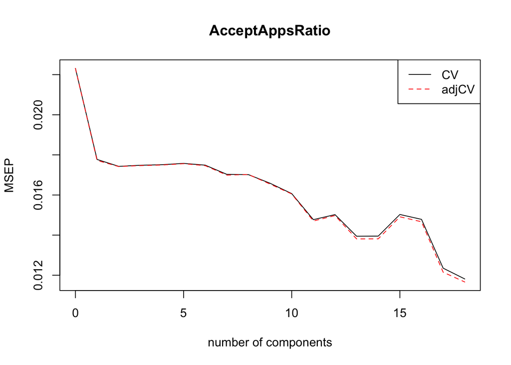

```r
# value of selected M:
validationplot(PCR, val.type = "MSEP", legendpos = "topright")
```

Based on the above plot(as well as the reuslt of summary()), we choose M = 18 as our selected value.  
And the testing error is 0.008436671.  
(d)  
Comment on the results obtained, comparing the results of ridge and lasso to your best reduced model from Homework 6. (That is, the reduced model from HW 6 that had the lowest test error).  
How accurately can we predict the acceptance rate overall? How much difference is there among the test errors resulting from different approaches? Which approach would you recommend for this dataset and why?  
In hw6, the best model selected is the one chosen by the smallest AIC, which has 10 predictors, and it’s training error is: 0.0095951475109477; it’s testing error is: 0.00843785749026494; and it’s CV error is: 0.01060228. Summarize the result in hw7:

```r
models <- c("ridge", "lasso", "PCR")
trainError <- c(trainerror_ridge, trainerror_lasso, 'NA')
testError <- c(testerror_ridge, testerror_lasso, PCRTestMSE)
CVerror <- c(cv_error_ridge,cv_error_lasso, 'NA' )

hw7 <- as.data.frame(cbind(models, trainError, testError, CVerror))
hw7
```

```
##   models          trainError           testError            CVerror
## 1  ridge 0.00957755771313214 0.00862810305778527 0.0111765676663485
## 2  lasso 0.00959228910147225  0.0085045682353921 0.0111768414513462
## 3    PCR                  NA  0.0084366708787259                 NA
```

As shown above, the results of ridge and lasso suggest that the testing error of the two are close. In this case, we choose lasso as a better model since it’s simpler.  
Compare the lasso model, the ridge model and the AIC model in hw6, the model selected by AIC still has the smallest testing error. All the testing error of the three are smaller than 0.01, which are really small. And this suggests that all these three models provides accurate prediction.  
It’s notable that the testing error of all these three models are really close, which suggests that testing error is not the best standard for us to tell which model is the best. In this case, we can focus on the complexity of these models.  
The ridge model include all predictors as the full model do, so this is not a good choice.  
The AIC model has 10 predictors, and for the lasso model, we have:

```r
lasso.coef =predict(lasso.mod, type="coefficients", s = bestlam.lasso)
lasso.coef
```

```
## 19 x 1 sparse Matrix of class "dgCMatrix"
##                         1
## (Intercept)  1.015617e+00
## PrivateYes   4.325712e-02
## Apps        -5.749517e-05
## Accept       8.727350e-05
## Enroll       .
## Top10perc   -4.133759e-04
## Top25perc   -8.432916e-04
## F.Undergrad  .
## P.Undergrad -6.612858e-06
## Outstate     .
## Room.Board  -1.762623e-05
## Books       -6.015144e-05
## Personal     5.968172e-06
## PhD         -3.916760e-04
## Terminal     .
## S.F.Ratio   -3.660850e-03
## perc.alumni  4.403225e-04
## Expend      -2.123198e-06
## Grad.Rate   -7.567306e-04
```

So the lasso model has (18-4) = 14 predictors, which suggests this model is more complex than the AIC selected model.  
Thus, the AIC selected model is the best model across all these models.